# Organized Shiny Code

Thuy Nguyen, JP Pedroza, Jim Wright, and Claire Zhang

5/25/2020

Background: This project will be a shiny app that will provide a quick look into data from three different years of the School Survey on Crime and Safety (05-06, 07-08, 17-18). The app will provide users with all the variables from these datasets that are matched between the different years. We are hoping that this shiny app will be able to provide general associations between continuous variables while being able to choose which year of the dataset the user is interested in as well as looking at differences between categories for any variable of interest. We are currently working on the shiny app and any feedback would be greatly appreciated, especially with the functions as they will be the base for the shiny app.

```r
files <- dir_ls(here::here("data"), glob = "*.csv")

batch <- map_df(files, read_csv)
batch
```

```
## # A tibble: 8,046 x 188
##       X1 schid c0110 c0112 c0114 c0116 c0120 c0122 c0134 c0136 c0138 c0140 c0142
##    <dbl> <dbl> <dbl> <dbl> <dbl> <dbl> <dbl> <dbl> <dbl> <dbl> <dbl> <dbl> <dbl>
##  1     1     3     1     2     2     2     2     2     1     1     2     2     2
##  2     2     4     1     1     2     2     2     1     2     1     2     2     2
##  3     3     8     1     2     2     2     2     1     2     1     1     2     2
##  4     4    10     1     1     2     2     2     2     2     2     1     2     2
##  5     5    13     1     1     2     2     2     1     1     1     1     2     2
##  6     6    14     1     1     2     2     2     1     2     1     2     1     2
##  7     7    15     1     2     2     2     2     2     2     1     1     2     2
##  8     8    16     1     2     2     2     2     2     2     1     1     2     2
##  9     9    17     1     1     2     2     2     2     2     2     1     2     2
## 10    10    18     1     1     1     2     1     1     2     1     1     2     2
## # … with 8,036 more rows, and 175 more variables: c0144 <dbl>, c0146 <dbl>,
## #   c0150 <dbl>, c0158 <dbl>, c0162 <dbl>, c0166 <dbl>, c0170 <dbl>,
## #   c0174 <dbl>, c0176 <dbl>, c0186 <dbl>, c0190 <dbl>, c0192 <dbl>,
## #   c0196 <dbl>, c0198 <dbl>, c0204 <dbl>, c0206 <dbl>, c0208 <dbl>,
## #   c0210 <dbl>, c0212 <dbl>, c0214 <dbl>, c0216 <dbl>, c0218 <dbl>,
## #   c0266 <dbl>, c0268 <dbl>, c0270 <dbl>, c0272 <dbl>, c0274 <dbl>,
## #   c0276 <dbl>, c0280 <dbl>, c0282 <dbl>, c0284 <dbl>, c0286 <dbl>,
## #   c0288 <dbl>, c0290 <dbl>, c0292 <dbl>, c0294 <dbl>, c0296 <dbl>,
## #   c0298 <dbl>, c0300 <dbl>, c0302 <dbl>, c0304 <dbl>, c0374 <dbl>,
## #   c0376 <dbl>, c0378 <dbl>, c0380 <dbl>, c0382 <dbl>, c0384 <dbl>,
## #   c0386 <dbl>, c0402 <dbl>, c0404 <dbl>, c0406 <dbl>, c0408 <dbl>,
## #   c0410 <dbl>, c0412 <dbl>, c0422 <dbl>, c0424 <dbl>, c0426 <dbl>,
## #   c0428 <dbl>, c0430 <dbl>, c0432 <dbl>, c0434 <dbl>, c0436 <dbl>,
## #   c0442 <dbl>, c0444 <dbl>, c0446 <dbl>, c0448 <dbl>, c0450 <dbl>,
## #   c0452 <dbl>, c0454 <dbl>, c0456 <dbl>, c0532 <dbl>, c0534 <dbl>,
## #   c0536 <dbl>, c0538 <dbl>, c0560 <dbl>, c0562 <dbl>, c0568 <dbl>,
## #   c0570 <dbl>, c0572 <dbl>, c0578 <chr>, c0578_yy <dbl>, strata <dbl>,
## #   fr_urban <chr>, fr_size <chr>, finalwgt <dbl>, ic0110 <dbl>, ic0112 <dbl>,
## #   ic0114 <dbl>, ic0116 <dbl>, ic0120 <dbl>, ic0122 <dbl>, ic0134 <dbl>,
## #   ic0136 <dbl>, ic0138 <dbl>, ic0140 <dbl>, ic0142 <dbl>, ic0144 <dbl>,
## #   ic0146 <dbl>, ic0150 <dbl>, ic0158 <dbl>, …
```

```r
batch <- batch %>%
  mutate(fr_ubran = as.factor(fr_urban),
         fr_size = as.factor(fr_size),
         year = as.factor(c0578_yy))
```

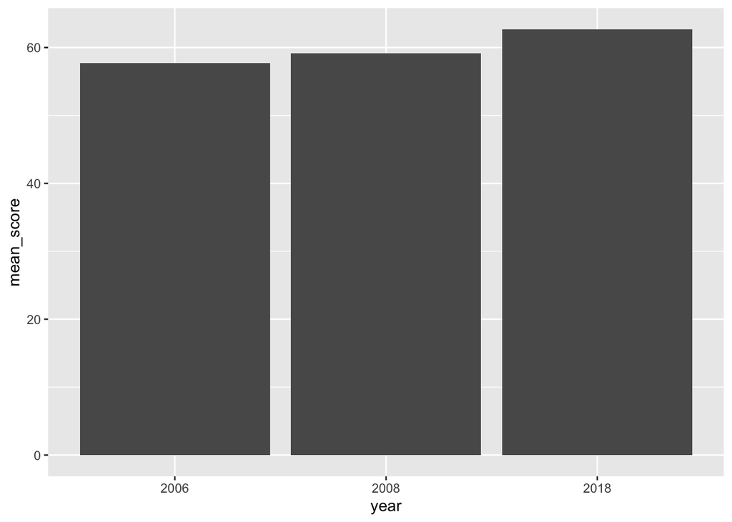

```r
batch %>%
  group_by(year) %>%
  nest() %>%
  mutate(mean_score = map_dbl(data, ~mean(.x$c0534))) %>%
  ggplot(aes(year, mean_score)) +
  geom_col()
```

```r
comparing <- batch %>%
  group_by(year) %>%
  nest() %>%
  mutate(model_1 = map(data, ~lm(c0534 ~ fr_urban, data = .x)),
         model_2 = map(data, ~lm(c0534 ~ fr_size, data = .x))) %>%
  mutate(model_compare = map2(model_1, model_2, stats::AIC),
         aic_model_1 = map_dbl(model_compare, list('AIC', 1)),
         aic_model_2 = map_dbl(model_compare, list('AIC', 2)))

compare_plot <- comparing %>%
  dplyr::select(year, aic_model_1, aic_model_2) %>%
  pivot_longer(-year, names_to = 'year_AIC', values_to = 'values')
```

```r
models <- batch %>%
  group_by(year) %>%
  nest() %>%
  mutate(model = map(data, ~lm(c0534 ~ c0562, data = .x))) %>%
  pivot_longer(model, names_to = 'model', values_to = 'output') %>%
  mutate(r2 = map_dbl(output, ~summary(.x)$r.squared))
```

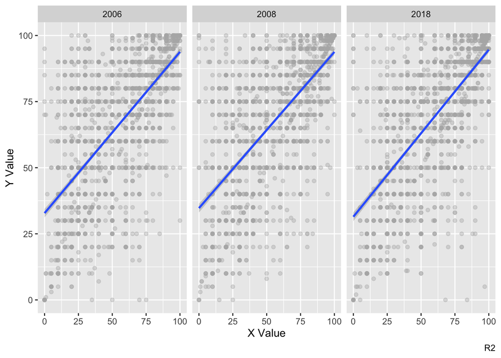

```r
# Function 1
numeric_plot <- function(df, x, y){
  plot_num <- ggplot({{df}}, aes({{x}}, {{y}})) +
      geom_point(alpha = .4, color = 'gray70') +
      geom_smooth(method = 'lm')

  if(!as.numeric({{x}}) & !as.numeric({{y}})){
    stop()
  }
  else{
    plot_num
  }
  return(plot_num)
}

numeric_plot(batch, batch$c0534, batch$c0536) +
  labs(x = 'X Value',
       y = 'Y Value',
       Title = 'A Title',
       caption = 'R2') +
  facet_wrap(~year)
```

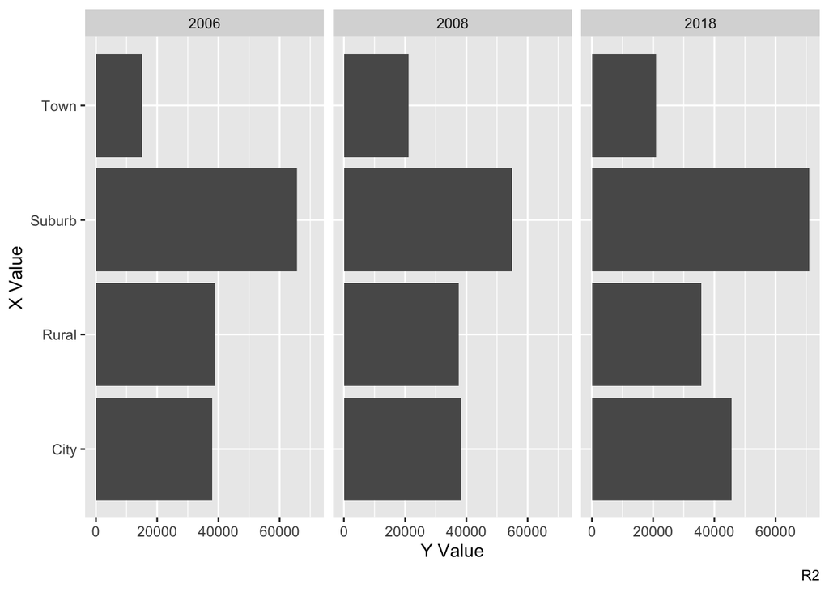

```r
# Function 2
bar_plot <- function(df, x, y, fill){
  plot_cat <- ggplot({{df}}, aes({{x}}, {{y}}, {{fill}})) +
  geom_col() +
  coord_flip()

  if(!as.numeric({{x}}) & !as.numeric({{y}})){
    stop()
  }
  else{
    plot_cat
  }
return(plot_cat)
}

bar_plot(batch, batch$fr_urban, batch$c0534, fill = batch$fr_urban) +
  labs(x = 'X Value',
       y = 'Y Value',
       Title = 'A Title',
       caption = 'R2') +
  facet_wrap(~year)
```

### Nest and Mutate (Claire Zhang)

I’ll use the original four years’ datasets (05-06, 07-08, 15-16, 17-18) from the NCES website, https://nces.ed.gov/surveys/ssocs/, and select variables of interest that are available across all four years including urbanicity, school size, percentage of low-performing students, percentage of college-going students, and total numbers of a) incidents reported, b) incidents reported to police, and c) out-of-school suspensions.

step 1, prepare four-year data:

```r
sf06 <- import(here("data_1", "pu_ssocs06_spss.sav"),
               setclass = "tbl_df") %>%
        select(urbanicity = FR_LOC4,
               size = FR_SIZE,
               low_performing = C0532,
               college_going = C0534,
               incidents = INCID06,
               incidents_police = INCPOL06,
               suspension = OUTSUS06) %>%
        mutate(year = "2006")
sf08 <- import(here("data_1", "pu_ssocs08_spss.sav"),
               setclass = "tbl_df") %>%
        select(urbanicity = FR_URBAN,
               size = FR_SIZE,
               low_performing = C0532,
               college_going = C0534,
               incidents = INCID08,
               incidents_police = INCPOL08,
               suspension = OUTSUS08)%>%
        mutate(year = "2008")
sf16 <- import(here("data_1", "pu_ssocs16.sas7bdat"),
               setclass = "tbl_df")%>%
        select(urbanicity = FR_URBAN,
               size = FR_SIZE,
               low_performing = C0532,
               college_going = C0534,
               incidents = INCID16,
               incidents_police = INCPOL16,
               suspension = OUTSUS16)%>%
        mutate(year = "2016")
sf18 <- import(here("data_1", "pu_ssocs18.sav"),
               setclass = "tbl_df")%>%
        select(urbanicity = FR_URBAN,
               size = FR_SIZE,
               low_performing = C0532,
               college_going = C0534,
               incidents = INCID18,
               incidents_police = INCPOL18,
               suspension = OUTSUS18)%>%
        mutate(year = "2018")
four_year <- bind_rows(sf06, sf08, sf16, sf18)%>%
  pivot_longer(cols = c(incidents, incidents_police, suspension),
                          names_to = "safety_indicators",
                          values_to = "total") %>%
  mutate(urbanicity = recode(urbanicity, '1' = "City", '2' = "Suburb", '3' = "Town", '4' = "Rural"),
         size = recode(size, '1' = "<300", '2' = "300-499", '3' = "500-999", '4' = "1,000+"),
         size = fct_relevel(size, "<300", "300-499", "500-999", "1,000+"))
```

step 2, inspect the four year data

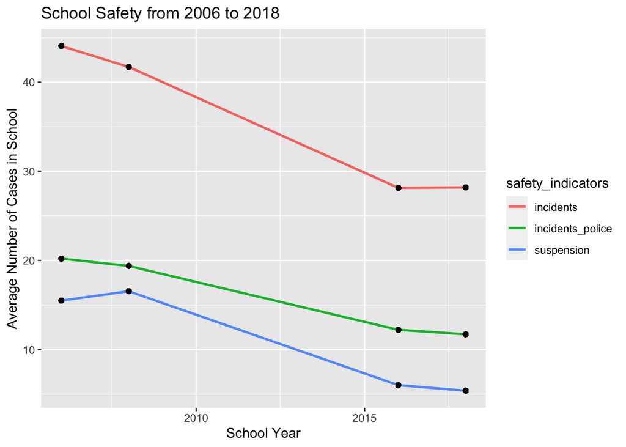

```r
full_plot1 <- four_year %>%
  group_by(year, safety_indicators) %>%
  mutate(mean = mean(total)) %>%
  ungroup() %>%
  mutate(year = readr::parse_number(year)) %>%
  ggplot(aes(year, mean))+
  geom_line(aes(color = safety_indicators), size = 0.9)+
  geom_point()+
  labs(title = "School Safety from 2006 to 2018",
       x = "School Year",
       y = "Average Number of Cases in School",
       fill = "Safety Indicators")

full_plot1
```

step 3, nest by year and visualize school safety, size, and urbanicity

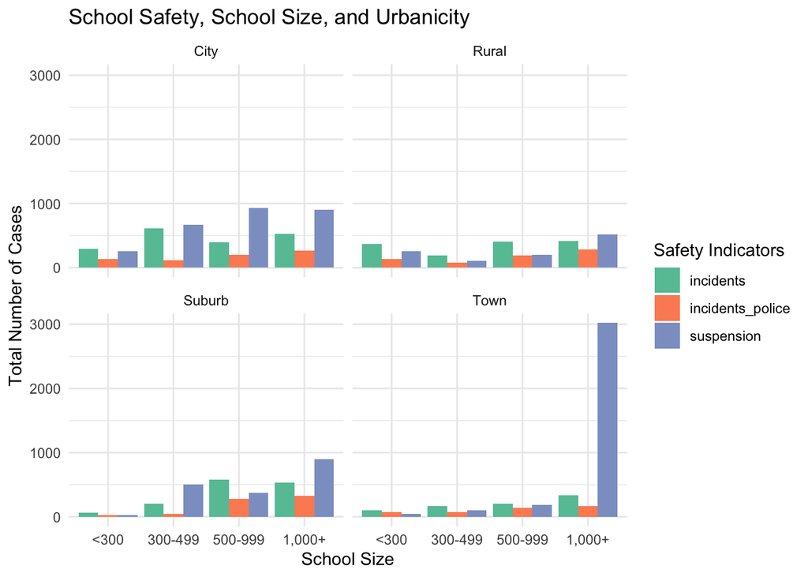

```r
plot1 <- function(x){
  x %>%
    ggplot(aes(size, total))+
    geom_col(aes(fill = safety_indicators),
             position = "dodge")+
    facet_wrap(~urbanicity)+
    theme_minimal()+
    scale_fill_brewer(palette = "Set2")+
    labs(title = "School Safety, School Size, and Urbanicity",
         x = "School Size",
         y = "Total Number of Cases",
         fill = "Safety Indicators")
}

plot1(four_year)
```

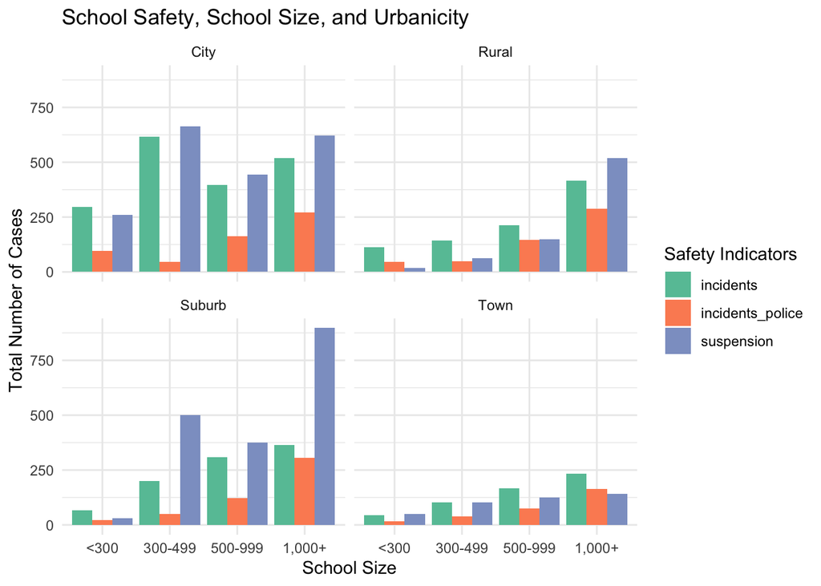

```r
plot1_by_year <- four_year %>%
  group_by(year) %>%
  nest() %>%
  mutate(plot = map(data, ~plot1(.x)))

plot1_by_year$plot[[1]]
```

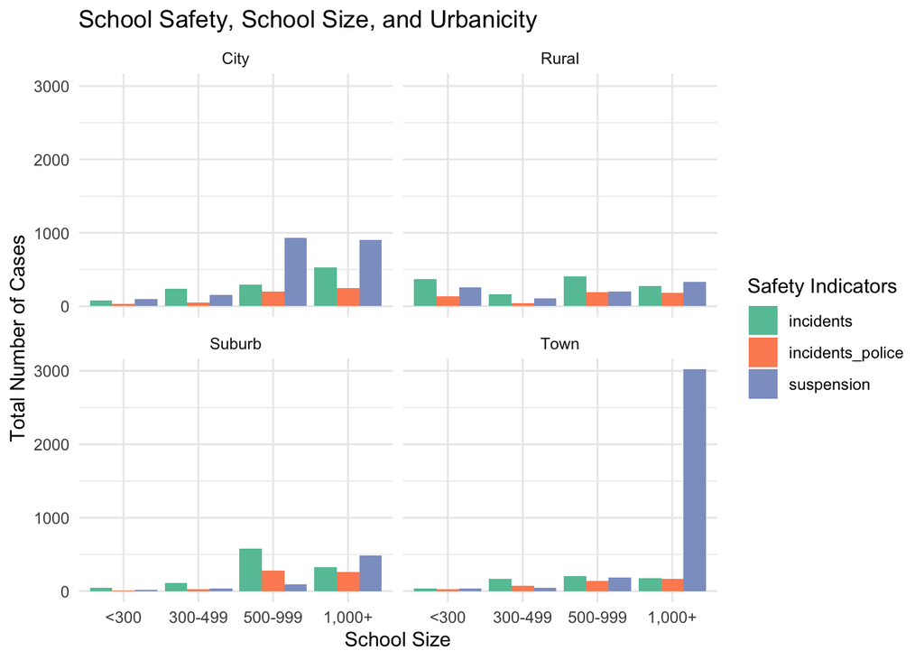

```r
plot1_by_year$plot[[2]]
```

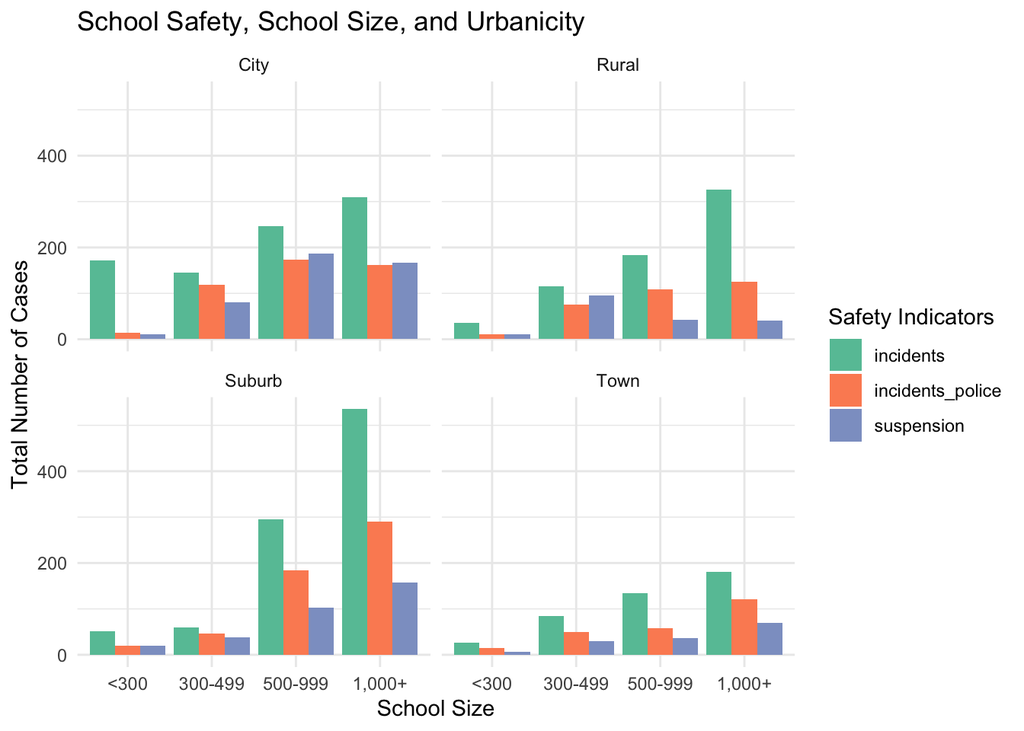

```r
plot1_by_year$plot[[3]]
```

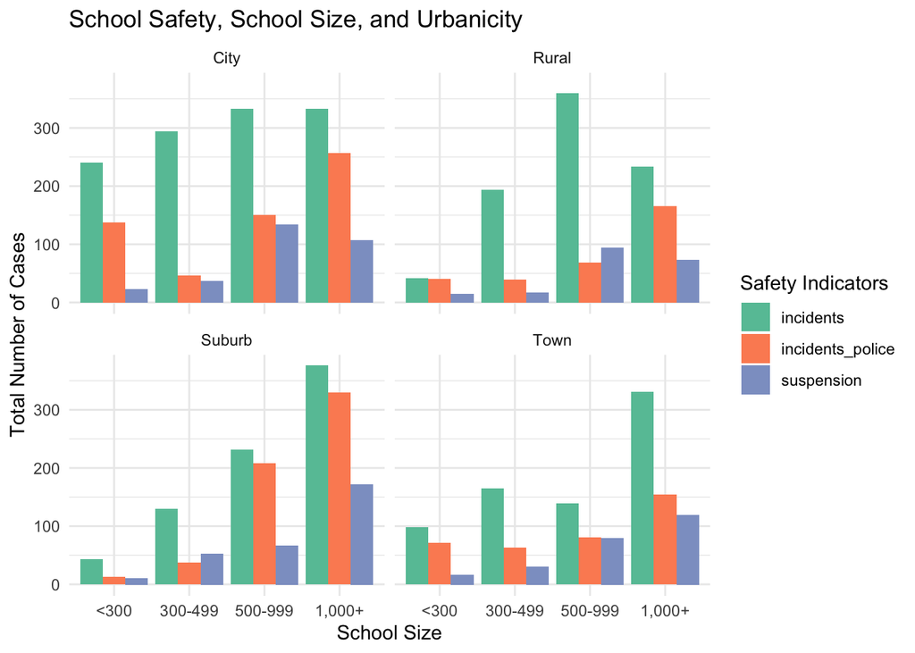

```r
plot1_by_year$plot[[4]]
```

```r
fs::dir_create(here::here("plots_1", "indicators"))


files <- plot1_by_year$year
paths <- here::here("plots_1", "indicators", glue("{files}.png"))
paths
```

```
## [1] "/Users/jimwright/Desktop/University of Oregon Courses/Terms/Spring 2020/spring2020_finalproj/plots_1/indicators/2006.png"
## [2] "/Users/jimwright/Desktop/University of Oregon Courses/Terms/Spring 2020/spring2020_finalproj/plots_1/indicators/2008.png"
## [3] "/Users/jimwright/Desktop/University of Oregon Courses/Terms/Spring 2020/spring2020_finalproj/plots_1/indicators/2016.png"
## [4] "/Users/jimwright/Desktop/University of Oregon Courses/Terms/Spring 2020/spring2020_finalproj/plots_1/indicators/2018.png"
```

```r
walk2(paths, plot1_by_year$plot, ggsave,
      width = 9.5,
      height = 6.5,
      dpi = 500)
```